# Virginia Community Policing Data: Highlighting Racial Disparities in Stops Across the Commonwealth

Frances Summers, Tenia Hicks, Winfred Rembert III

2026-04-30

# Police Violence in Black communities & The Community Policing Act

After the murder of George Floyd by Minneapolis police officers in 2020, protesters across the nation took to the streets demanding police accountability and protection of Black communities. Following immense political pressure to address systemic police violence, Virginia passed a series of legislation aiming to reform law enforcement agencies with measures banning no-knock warrants, neck restraints, and firing into a moving vehicle. These reforms aim to put additional checks onto Virginia police agencies and reduce racial disparities in police stops and use of force in an effort to address the needs of Virginia residents. The Virginia Community Policing Act, enacted in 2021, requires police agencies to report every stop by an officer to VA state police in an effort to increase transparency and evaluate the efficacy of these reforms.

This project uses data collected under the Virginia Community Policing Act to examine patterns in police stops and officer behavior across the state. The dataset includes detailed information on each stop, such as the race, ethnicity, age, and gender of individuals, as well as the reason for the stop and any resulting actions, including searches, arrests, and use of force. The accompanying HTML dashboard presents a series of visualizations that explore these patterns, with a particular focus on racial disparities in stops, searches, and use of force. By translating this statewide data into accessible charts, the project aims to assess whether recent policy reforms have reduced inequities in policing and to highlight areas where disparities persist.

# Racial Disparities in Police Stops

This bar chart compares each racial group’s share of Virginia’s total population against their share of traffic stops. Black or African American drivers are significantly over-represented in stops, making up 19% of the population but accounting for 30.4% of all traffic stops. Conversely, White drivers are stopped at a lower rate relative to their population share (66.3% of the population vs. 55.8% of stops), pointing to a clear racial disparity in who gets pulled over.

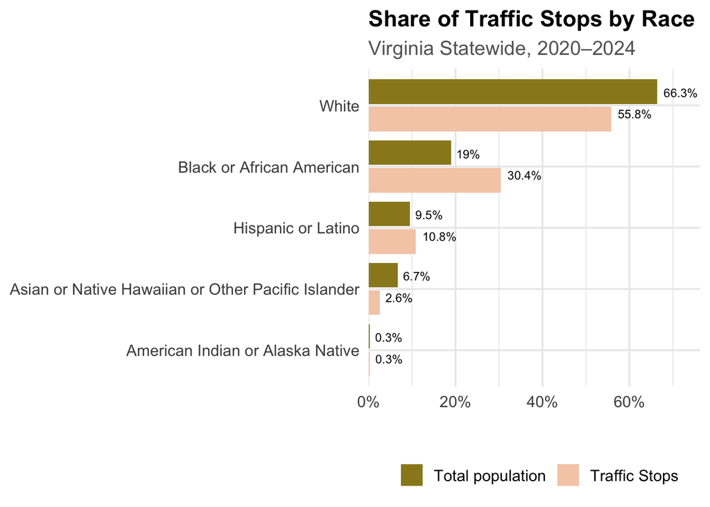

```r
#Share of stops as a proportion of county population, by race in Virginia 2020-2024
stop_by_pop <- VAStops %>%
  mutate(race = ifelse(ethnicity == "Hispanic or Latino", "Hispanic or Latino", race)) %>%
  filter(!is.na(race), !race %in% c("Unknown", "Missing")) %>%
  count(county_clean, race, name = "total_stops") %>%
  mutate(pct_of_stops = total_stops / sum(total_stops) * 100)

stop_by_pop_STATE <- stop_by_pop %>%
                        group_by(race) %>%
                        summarize(total = sum(total_stops)) %>%
                        mutate(pct = total / sum(total) * 100)

State.pop <- as.vector(va_demog[1, c(13, 11, 7, 9, 5)], mode = "numeric")
State.pct <- State.pop/va_demog$tot_popE[1] * 100

stop_by_pop_STATE <- cbind(stop_by_pop_STATE, State.pop, State.pct)

stop_by_pop_STATE %>%
  ggplot(aes(x = reorder(race, pct), y = pct)) +
  geom_col(aes(fill = "Traffic Stops"), width = 0.4, position = position_nudge(x = -0.225)) +
  geom_text(aes(label = paste0(round(pct, 1), "%")),
            size = 3, vjust = 1.5, hjust = -0.2) +
  geom_col(aes(y = State.pct, fill = "Total population"), width = 0.4, position = position_nudge(x = 0.225)) +
  geom_text(aes(y = State.pct, label = paste0(round(State.pct, 1), "%")),
            size = 3, vjust = -1, hjust = -0.2) +
  coord_flip() +
  scale_fill_manual(name = "", values = wes_palette("Royal2", n = 2)) +
  scale_y_continuous(expand = expansion(mult = c(0, 0.15)),
                     labels = scales::percent_format(scale = 1)) +
  labs(
    title = "Share of Traffic Stops by Race",
    subtitle = "Virginia Statewide, 2020–2024",
    x = NULL, y = ""
  ) +
  theme_minimal(base_size = 14) +
  theme(
    legend.position = "bottom",
    plot.title = element_text(face = "bold", size = 16),
    plot.subtitle = element_text(color = "gray40"))
```

## Use of Force, by Agency (2020-2025)

```r
#interactive table version
library(DT)

agency_table <- VAStops %>%
  filter(!is.na(county_clean)) %>%
  group_by(year, agency_name, county_clean) %>%
  summarize(
    total_stops = n(),
    force_count = sum(force_used_by_officer == "Y", na.rm = TRUE),
    force_rate = round(force_count / total_stops * 100, 3),
    pct_black = round(mean(race == "Black or African American", na.rm = TRUE) * 100, 1),
    pct_male_stopped = round(mean(gender == "Male", na.rm = TRUE) * 100, 1),
    .groups = "drop"
  ) %>%
  filter(total_stops >= 500) %>%
  arrange(desc(force_rate))

datatable(
  agency_table,
  colnames = c("Year", "Agency", "County", "Total Stops", "Force Incidents",
               "Force Rate (%)", "% Black Stopped", "% Male Stopped"),
  filter = "top",
  options = list(
    pageLength = 10,
    scrollX = TRUE
  ),
  rownames = FALSE
)
```

| Year | Agency | County | Total Stops | Force Incidents | Force Rate (%) | % Black Stopped | % Male Stopped |
| --- | --- | --- | --- | --- | --- | --- | --- |
| 2024 | Washington Metro Area Transit PD | Fairfax CO | 864 | 42 | 4.861 | 69.2 | 82.6 |
| 2023 | Washington Metro Area Transit PD | Arlington CO | 1171 | 45 | 3.843 | 75.4 | 75.7 |
| 2024 | Charlottesville Police Department | Charlottesville City City | 2774 | 90 | 3.244 | 28.9 | 60.5 |
| 2025 | Campbell County Sheriff's Office | Campbell CO | 1955 | 63 | 3.223 | 25.3 | 62.6 |
| 2024 | Campbell County Sheriff's Office | Campbell CO | 2243 | 67 | 2.987 | 21.2 | 59.1 |
| 2022 | Campbell County Sheriff's Office | Campbell CO | 1924 | 57 | 2.963 | 20.9 | 55.4 |
| 2025 | Washington Metro Area Transit PD | Arlington CO | 1265 | 34 | 2.688 | 74.4 | 75 |
| 2022 | Charlottesville Police Department | Charlottesville City City | 3767 | 97 | 2.575 | 29.5 | 60.3 |
| 2024 | Washington Metro Area Transit PD | Arlington CO | 1227 | 30 | 2.445 | 73.3 | 83.4 |
| 2025 | Charlottesville Police Department | Charlottesville City City | 5106 | 114 | 2.233 | 28.2 | 60.5 |

[output cut: 1634 more lines]

This demonstrates the action of stopping a Virginian driver. What follows from this action by the officer, including warning, citations, or use of force, demonstrates the impact of national-level violence on Black and African American communities onto the police agencies’ actions.

The following graph illustrates the differences between actions by the officer for different racial groups.

# What Happens to Virginians After a Traffic Stop?

This grouped bar chart breaks down post-stop outcomes: arrest, citation/summons, no enforcement action, and warning, by racial group. Hispanic drivers face the highest arrest rate at 5.9%, followed by 3.8% for Black drivers, 2.4% for Asian/PI drivers, 1.8% for White drivers, and just 0.9% for Native American drivers. Hispanic drivers also have the highest percentage of citations/summons in comparison to other ethnic backgrounds. Across most of the outcomes the differences are relatively modest.

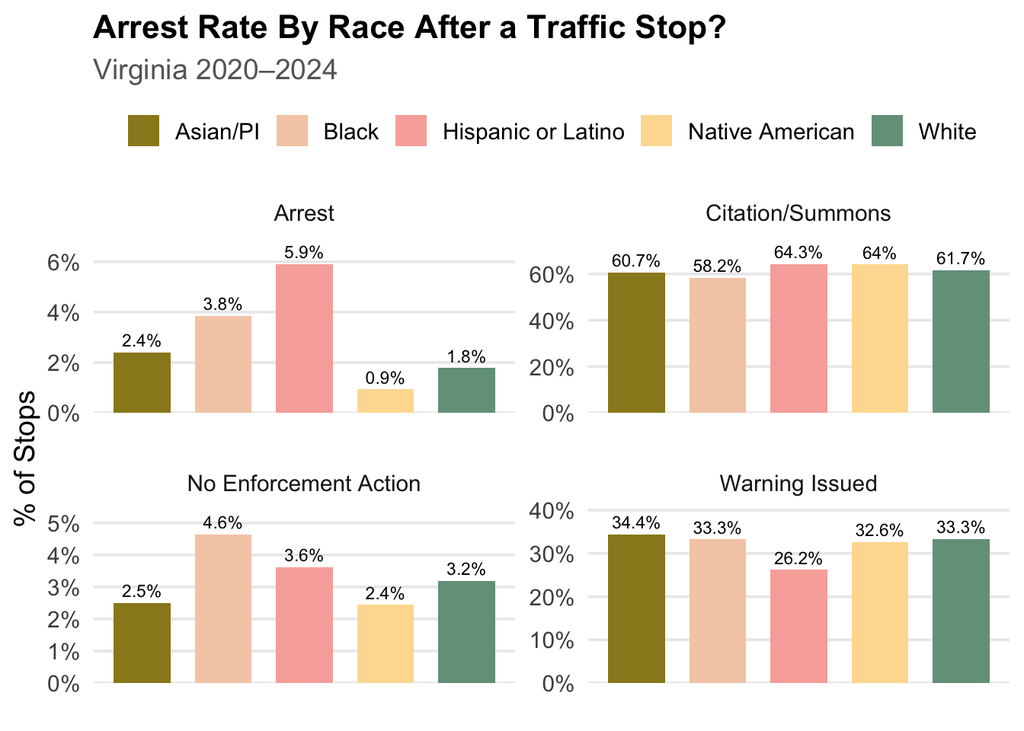

```r
#Action_taken by race in Virginia 2020-2024
action_by_race <- VAStops %>%
  mutate(race = ifelse(ethnicity == "Hispanic or Latino", "Hispanic or Latino", race)) %>%
  filter(!is.na(race), !race %in% c("Unknown", "Missing"),
         action_taken != "Missing") %>%
  count(race, action_taken) %>%
  group_by(race) %>%
  mutate(pct = n / sum(n) * 100) %>%
  ungroup()

#recode to shorten
action_by_race <- action_by_race %>%
  mutate(race = recode(race,
                       "Black or African American" = "Black",
                       "Asian or Native Hawaiian or Other Pacific Islander" = "Asian/PI",
                       "American Indian or Alaska Native" = "Native American"))

action_by_race %>%
  ggplot(aes(x = race, y = pct, fill = race)) +
  geom_col(position = "dodge", width = 0.7) +
  geom_text(aes(label = paste0(round(pct, 1), "%")),
            position = position_dodge(width = 0.7),
            vjust = -0.5, size = 3) +
  scale_fill_manual(values = wes_palette("Royal2", n = 5)) +
  scale_y_continuous(expand = expansion(mult = c(0, 0.2)),
                     labels = scales::percent_format(scale = 1)) +
  scale_x_discrete(labels = c("", "", "", "", "")) +
  facet_wrap(~ action_taken, scales = "free") +
  labs(
    title = "Arrest Rate By Race After a Traffic Stop?",
    subtitle = "Virginia 2020–2024",
    x = NULL, y = "% of Stops", fill = NULL
  ) +
  theme_minimal(base_size = 14) +
  theme(
    legend.position = "top",
    plot.title = element_text(face = "bold", size = 16),
    plot.subtitle = element_text(color = "gray40"),
    panel.grid.major.x = element_blank(),
    panel.grid.minor = element_blank())
```

## Arrest Rate Over Time

[figure not shown]

```r
#Arrest rate over time in Virginia, 2020-2024 (by race)
arrest_over_time <- VAStops %>%
  mutate(race = ifelse(ethnicity == "Hispanic or Latino", "Hispanic or Latino", race)) %>%
  filter(!is.na(race), !race %in% c("Unknown", "Missing"),
         action_taken != "Missing") %>%
  mutate(year = year(date)) %>%
  count(year, race, action_taken) %>%
  group_by(year, race) %>%
  mutate(pct = n / sum(n) * 100) %>%
  ungroup() %>%
  filter(action_taken == "Arrest")

arrest_over_time %>%
  mutate(race = recode(race,
                       "Black or African American" = "Black",
                       "Asian or Native Hawaiian or Other Pacific Islander" = "Asian/PI",
                       "American Indian or Alaska Native" = "Native American"
  )) %>%
  ggplot(aes(x = year, y = pct, color = race)) +
  geom_line(linewidth = 1.2) +
  geom_point(size = 3) +
  scale_y_continuous(
    limits = c(0, 8),
    breaks = seq(0, 8, by = 1),
    labels = scales::percent_format(scale = 1)) +
  scale_color_manual(values = wes_palette("Royal2", n = 5)) +
  labs(
    title = "Arrest Rate by Race Over Time",
    subtitle = "% of traffic stops resulting in arrest across Virginia, 2020–2024",
    x = NULL, y = "% Arrested", color = NULL
  ) +
  theme_minimal(base_size = 14) +
  theme(
    legend.position = "none",
    plot.title = element_text(face = "bold", size = 16),
    plot.subtitle = element_text(color = "gray40"),
    panel.grid.minor = element_blank()
  ) +
  annotate("text", x = 2021, y = 5.6, label = "Hispanic or Latino", color = "#F8AFA8", size = 4)+
  annotate("text", x = 2022, y = 5.3, label = "Black", color = "#E1BD6D", size = 4)+
  annotate("text", x = 2022, y = 3.5, label = "Asian/PI", color = "#9A8822", size = 4)+
  annotate("text", x = 2023, y = 1.3, label = "Native American", color = "#E1BD6D", size = 4)+
  annotate("text", x = 2023, y = 2.4, label = "White", color = "#74A089", size = 4)
```

## Use of Force by VA Police since 2021*

This line chart shows the percentage of traffic stops in Virginia that involved use of force, measured at roughly quarterly intervals. The rate was near zero through early 2021, then surged sharply to around 0.19-0.21% this likely reflects a change in reporting requirements or data collection practices rather than a sudden behavioral shift. After reaching a peak in mid-2022, the rate stabilized and fluctuated narrowly between roughly 0.16% and 0.20% through 2024.

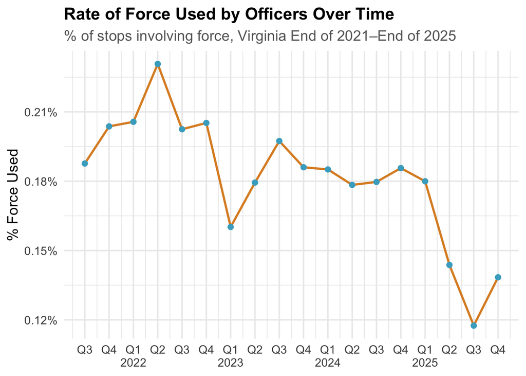

```r
vacpd_byquarter <- VAStops %>%
  filter(year >= 2020 & year <= 2025) %>%
  group_by(year, quarter) %>%
  summarize(
    tot_stops = n(),
    force_by_officer = sum(force_used_by_officer == "Y", na.rm = TRUE),
    force_rate = force_by_officer / tot_stops * 100
  ) %>%
  mutate(year_qtr = year + (quarter - 1) / 4)

vacpd_byquarter %>%
  filter(force_by_officer > 0) %>%
  ggplot(aes(x = year_qtr, y = force_rate)) +
  geom_line(linewidth = 1, color = wes_palette("FantasticFox1")[1]) +
  geom_point(size = 2, color = wes_palette("FantasticFox1")[3]) +
  scale_x_continuous(
    breaks = vacpd_byquarter %>% filter(force_by_officer > 0) %>% pull(year_qtr),
    labels = vacpd_byquarter %>% filter(force_by_officer > 0) %>%
      mutate(lbl = ifelse(quarter == 1, paste0("Q1\n", year), paste0("Q", quarter))) %>%
      pull(lbl)
  ) +
  scale_y_continuous(labels = scales::percent_format(scale = 1)) +
  labs(
    title = "Rate of Force Used by Officers Over Time",
    subtitle = "% of stops involving force, Virginia End of 2021–End of 2025",
    x = NULL, y = "% Force Used"
  ) +
  theme_minimal(base_size = 14) +
  theme(
    plot.title = element_text(face = "bold", size = 16),
    plot.subtitle = element_text(color = "gray40")
  )
```

The following visualizations illustrate the use of force in the stop itself. While this dataset measures use of force by officer and by person stopped, we decided to focus on use of force by officer onto the individual stopped. We found that the use of force varied by race, by county, and by agency. This demonstrates that the use of force by officer, while it has been tracked in this dataset, should continue to be measured with a critical eye.

## Use of Force by VA Police by County

[figure not shown]

```r
top_counties <- VAStops %>%
  distinct(county_clean, .keep_all = TRUE) %>%
  arrange(desc(population)) %>%
  select(county_clean, population) %>%
  head(10)

force_by_county <- VAStops %>%
  filter(county_clean %in% top_counties$county_clean) %>%
  group_by(county_clean) %>%
  summarize(
    total_stops = n(),
    force_count = sum(force_used_by_officer == "Y", na.rm = TRUE),
    force_rate = force_count / total_stops * 100
  )

# Raw count of force used by officer
p1 <- ggplot(force_by_county, aes(x = reorder(county_clean, force_count), y = force_count)) +
  geom_col(width = 0.6, fill = wes_palette("Darjeeling1")[1]) +
  geom_text(aes(label = force_count), hjust = -0.1, size = 3) +
  coord_flip() +
  scale_y_continuous(expand = expansion(mult = c(0, 0.15))) +
  labs(
    title = "Count of Stops Involving Force",
    x = NULL, y = "Number of Stops"
  ) +
  theme_minimal(base_size = 12) +
  theme(panel.grid.major.y = element_blank())

# Rate of force used
p2 <- ggplot(force_by_county, aes(x = reorder(county_clean, force_rate), y = force_rate)) +
  geom_col(width = 0.6, fill = wes_palette("Darjeeling1")[2]) +
  geom_text(aes(label = paste0(round(force_rate, 2), "%")), hjust = -0.1, size = 3) +
  coord_flip() +
  scale_y_continuous(expand = expansion(mult = c(0, 0.2)),
                     labels = scales::percent_format(scale = 1)) +
  labs(
    title = "Rate of Force Used",
    x = NULL, y = "% of Stops"
  ) +
  theme_minimal(base_size = 12) +
  theme(panel.grid.major.y = element_blank())

library(patchwork)
p1 + p2 +
  plot_annotation(
    title = "Force Used by County: Count vs. Rate",
    subtitle = "Top 20 Virginia counties by population from 2020–2024",
    theme = theme(
      plot.title = element_text(face = "bold", size = 16),
      plot.subtitle = element_text(color = "gray40", size = 12)
    )
  )
```

# Racial Disparities in Use of Force

## Use of Force by Race

This graph shows the total number of use-of-force incidents by race across Virginia from 2020–2024. Black or African American individuals account for the highest number of incidents (3,734), followed closely by White individuals (3,473), with substantially lower counts for Hispanic or Latino individuals (1,435) and very small numbers for other groups. This suggests that Black individuals experienced the most use-of-force incidents overall during this period.

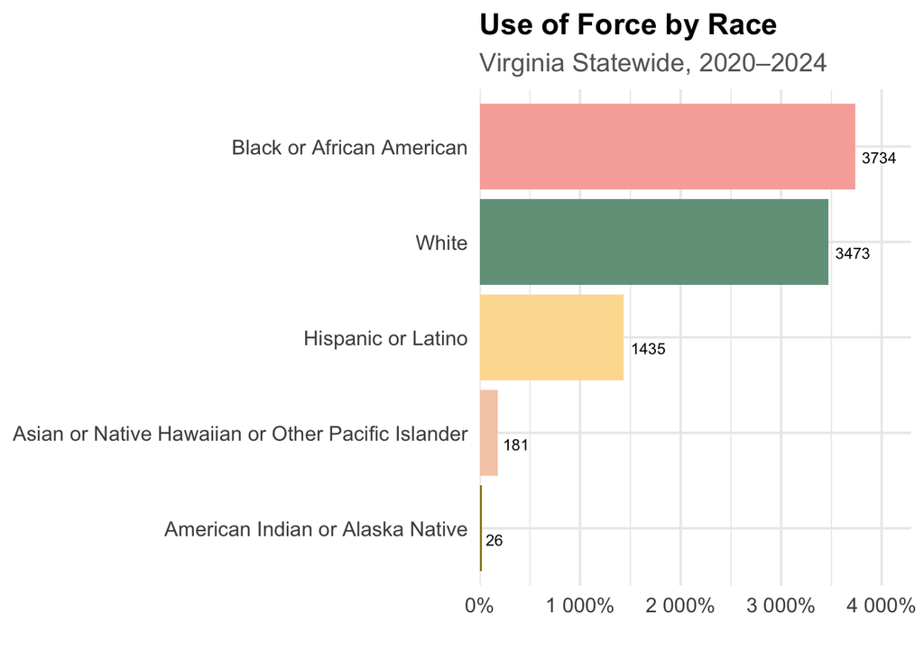

```r
#Use of Force by Race
Use_of_Force <- VAStops %>%
                  mutate(race = ifelse(ethnicity == "Hispanic or Latino", "Hispanic or Latino", race)) %>%
                  filter(!is.na(race), !race %in% c("Unknown", "Missing"),
                         action_taken != "Missing") %>%
                  group_by(race) %>%
                  summarize(
                    Total_Stops = n(),
                    Total_UoF = sum(force_used_by_officer == "Y"),
                    UoF_pct = Total_UoF/Total_Stops * 100
                  )

#GRAPH By race - Total Use of Force
Use_of_Force %>%
  ggplot(aes(x = reorder(race, Total_UoF), y = Total_UoF, fill = race)) +
  geom_col() +
  geom_text(aes(label = paste0(round(Total_UoF, 3))),
            size = 3, vjust = 1.5, hjust = -0.2) +
  coord_flip() +
  scale_fill_manual(name = "", values = wes_palette("Royal2", n = 5)) +
  scale_y_continuous(expand = expansion(mult = c(0, 0.15)),
                     labels = scales::percent_format(scale = 1)) +
  labs(
    title = "Use of Force by Race",
    subtitle = "Virginia Statewide, 2020–2024",
    x = NULL, y = ""
  ) +
  theme_minimal(base_size = 14) +
  theme(
    legend.position = "none",
    plot.title = element_text(face = "bold", size = 16),
    plot.subtitle = element_text(color = "gray40"))
```

## Use of Force Rate by Race

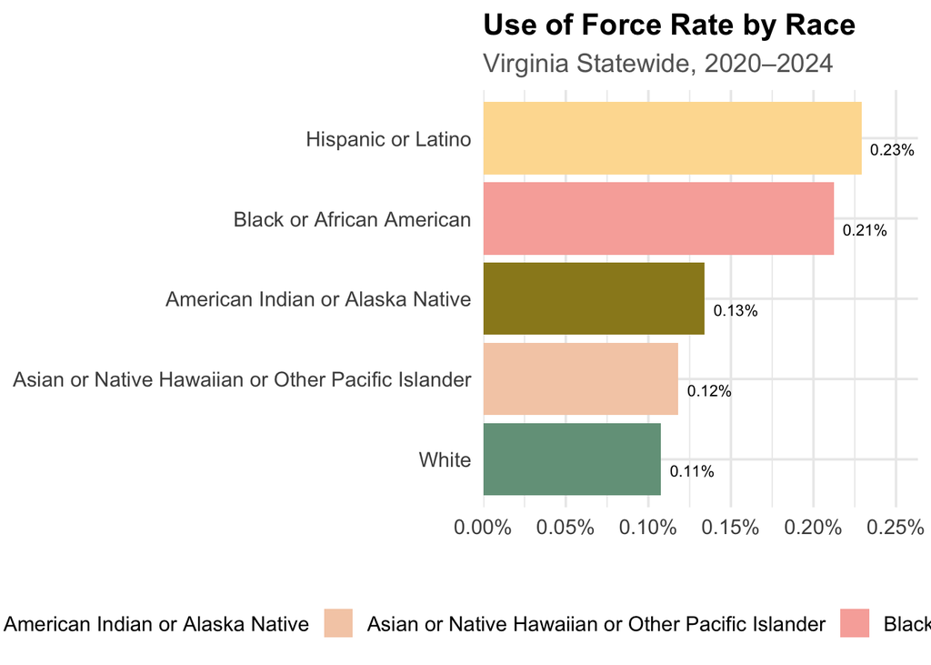

```r
#GRAPH By race - Use of Force Rate
Use_of_Force %>%
  ggplot(aes(x = reorder(race, UoF_pct), y = UoF_pct, fill = race)) +
  geom_col() +
  geom_text(aes(label = paste0(round(UoF_pct, 2), "%")),
            size = 3, vjust = 1.5, hjust = -0.2) +
  coord_flip() +
  scale_fill_manual(name = "", values = wes_palette("Royal2", n = 5)) +
  scale_y_continuous(expand = expansion(mult = c(0, 0.15)),
                     labels = scales::percent_format(scale = 1)) +
  labs(
    title = "Use of Force Rate by Race",
    subtitle = "Virginia Statewide, 2020–2024",
    x = NULL, y = ""
  ) +
  theme_minimal(base_size = 14) +
  theme(
    legend.position = "bottom",
    plot.title = element_text(face = "bold", size = 16),
    plot.subtitle = element_text(color = "gray40"))
```

In addition to the use of force by the officer, it is essential to understand the baseline differences between counties, and by proxy the police agencies that are housed there, and these effects on the stop data.

The following graph illustrates the poverty rate and the presence of police agencies in Virginia counties.

# Police Workforce by County Poverty Rate

This graph shows the poverty rate and police workforce of each VA county. Here, we see a positive relationship between the number of officers per capita and the percentage of county residents below the poverty line, showing that there are more police present in lower income communities. This indicates that counties may see an increased police force as a potential avenue to tackling poverty in their communities.

```r
#Load in fbi data
Officer_Workforce <- readRDS("fbi_lee.RDS")

#Clean FBI county data to match full dataset
Officer_Workforce <- Officer_Workforce %>%
                      filter(county_name != "UNMAPPED COUNTY") %>%
                      filter(county_name != "NOT SPECIFIED") %>%
                      mutate(county_clean = str_to_title(county_name)) %>%
                      mutate(county_clean = case_when(
                        county_clean == "Augusta, Rockingham" ~ "Rockingham",
                        county_clean == "Cumberland, Prince Edward" ~ "Prince Edward",
                        county_clean == "Lancaster, Northumberland" ~ "Lancaster",
                        county_clean == "Russell, Wise" ~ "Russell",
                        county_clean == "Smyth, Washington" ~ "Smyth",
                        county_clean == "King And Queen" ~ "King and Queen",
                        county_clean == "Isle Of Wight" ~ "Isle of Wight",
                        TRUE ~ county_clean
                      )) %>%
                      arrange(data_year) %>%
                      distinct(agency_clean, .keep_all = TRUE) %>%
                      group_by(county_clean) %>%
                      summarize(
                        n_agencies = n(),
                        Total_Offi = sum(officer_ct)
                      )

#Summary of population information by County
CountySumm <- VAStops %>%
                group_by(county_clean) %>%
                summarize(
                    Total_pop = first(tot_popE),
                    Total_stops = n(),
                    Stops_per_pers = n()/first(tot_popE),
                    Wh_pop = first(whiteE),
                    Bl_pop = first(BlackE),
                    API_pop = first(asianE),
                    La_pop = first(HispanicE),
                    Pov_pop = first(povertyE),
                    Wh_pct = first(whiteE)/first(tot_popE) * 100,
                    Bl_pct = first(BlackE)/first(tot_popE) * 100,
                    API_pct = first(asianE)/first(tot_popE) * 100,
                    La_pct = first(HispanicE)/first(tot_popE) * 100,
                    Pov_pct = first(povertyE)/first(tot_popE) * 100,
                    Total_UoF = sum(force_used_by_officer == "Y"),
                    UoF_per_pers = sum(force_used_by_officer == "Y")/first(tot_popE)
                  )
CountySumm <- CountySumm %>%
  mutate(county_clean = county_clean %>%
           str_replace(" CO$", "") %>%
           str_replace("City City City", "City") %>%
           str_replace("City City", "City") %>%
           str_replace("County City", "") %>%
           str_trim()
  )


va_counties <- get_acs(
  geography = "county",
  state = "VA",
  variables = c(
    tot_pop = "B01003_001",
    poverty = "B17001_002"
  ),
  year = 2020,
  geometry = TRUE,
  output = "wide"
) %>%
  mutate(county_clean = NAME %>%
           str_to_title() %>%
           str_replace(", Virginia", "") %>%
           str_replace(" County", "") %>%
           str_replace("King And Queen", "King and Queen") %>%
           str_replace("Isle Of Wight", "Isle of Wight")
  )

pop_lookup <- va_counties %>%
  as.data.frame() %>%
  select(county_clean, tot_popE, povertyE)

CountySumm <- CountySumm %>%
  select(-Pov_pop) %>%
  left_join(pop_lookup, by = "county_clean")

Officer_pop <- CountySumm %>%
  left_join(Officer_Workforce, by = "county_clean") %>%
  filter(!is.na(county_clean), !is.na(tot_popE), !is.na(Total_Offi)) %>%
  mutate(
    Offi_per_1000 = Total_Offi / tot_popE * 1000,
    Pov_pct = povertyE / tot_popE * 100
  )
```

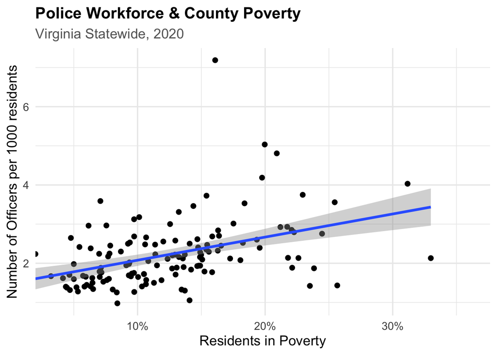

```r
#Graph Police Workforce & Poverty Rate
Officer_pop %>%
  ggplot(aes(x = Pov_pct, y = Offi_per_1000)) +
  geom_point() +
  geom_smooth(method = "lm") +
  scale_x_continuous(expand = expansion(mult = c(0, 0.15)),
                     labels = scales::percent_format(scale = 1)) +
  labs(
    title = "Police Workforce & County Poverty",
    subtitle = "Virginia Statewide, 2020",
    x = "Residents in Poverty", y = "Number of Officers per 1000 residents"
  ) +
  theme_minimal(base_size = 14) +
  theme(
    plot.title = element_text(face = "bold", size = 16),
    plot.subtitle = element_text(color = "gray40"))
```

# Does Having Women in the Police Agency Affect Use of Force During Stops?

Lastly, we wanted to discover the impact of the demographics of the police agency itself. We wanted to know if women in the agency overall has an effect on the use of force by officers. We hypothesized that women in the agency makes the other officers “less forceful” when completing stops in the county.

## Women in the Agency for Highest Use of Force Rates across the state

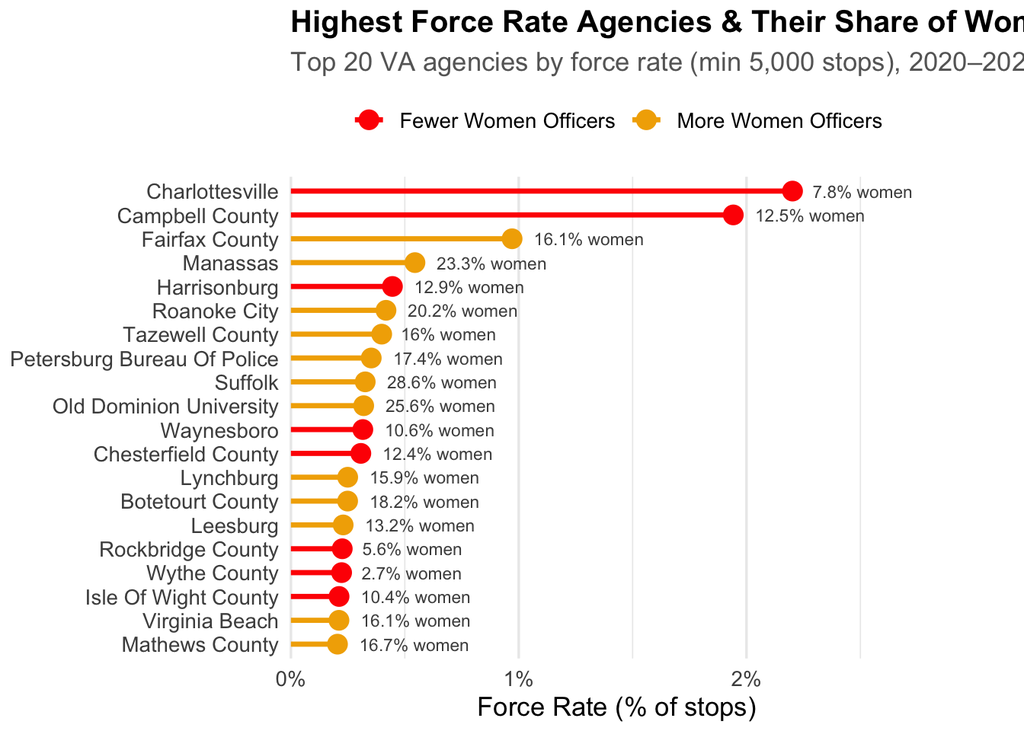

```r
officer_gender_force <- VAStops %>%
  filter(!is.na(county_clean), !is.na(officer_ct), officer_ct > 0) %>%
  group_by(agency_name) %>%
  summarize(
    total_stops = n(),
    force_count = sum(force_used_by_officer == "Y", na.rm = TRUE),
    force_rate = force_count / total_stops * 100,
    female_officers = first(na.omit(female_officer_ct)),
    total_officers = first(na.omit(officer_ct)),
    pct_female = round(female_officers / total_officers * 100, 1),
    .groups = "drop"
  ) %>%
  filter(total_stops >= 5000, !is.na(pct_female)) %>%
  mutate(
    agency_short = agency_name %>%
      str_replace(" Police Department", "") %>%
      str_replace(" Police Dept", "") %>%
      str_replace(" Sheriff's Office", "") %>%
      str_trim(),
    female_group = ifelse(pct_female >= median(pct_female),
                          "More Women Officers",
                          "Fewer Women Officers")
  ) %>%
  arrange(desc(force_rate)) %>%
  head(20)

ggplot(officer_gender_force,
       aes(x = reorder(agency_short, force_rate), y = force_rate, color = female_group)) +
  geom_segment(aes(xend = agency_short, y = 0, yend = force_rate), linewidth = 1.2) +
  geom_point(size = 4) +
  geom_text(aes(label = paste0(pct_female, "% women")),
            hjust = -0.2, size = 3, color = "gray30") +
  coord_flip(clip = "off") +
  scale_color_manual(values = wes_palette("Darjeeling1")[c(1, 3)]) +
  scale_y_continuous(expand = expansion(mult = c(0, 0.3)),
                     labels = scales::percent_format(scale = 1)) +
  labs(
    title = "Highest Force Rate Agencies & Their Share of Women Officers",
    subtitle = "Top 20 VA agencies by force rate (min 5,000 stops), 2020–2025",
    x = NULL, y = "Force Rate (% of stops)", color = NULL
  ) +
  theme_minimal(base_size = 13) +
  theme(
    legend.position = "top",
    plot.title = element_text(face = "bold", size = 15),
    plot.subtitle = element_text(color = "gray40"),
    panel.grid.major.y = element_blank(),
    plot.margin = margin(5, 40, 5, 5)
  )
```

Evidently, the agencies with more women still use force in stops.

We also observed the hiring of women officers over time. Using the agency dataset, we observed the count of women officers over time. Similarly, we hypothesized that over time, an agency would “self-correct” and use less force in their stops.

## Women in the Agency Over Time and the Effect on Force Used During Stops

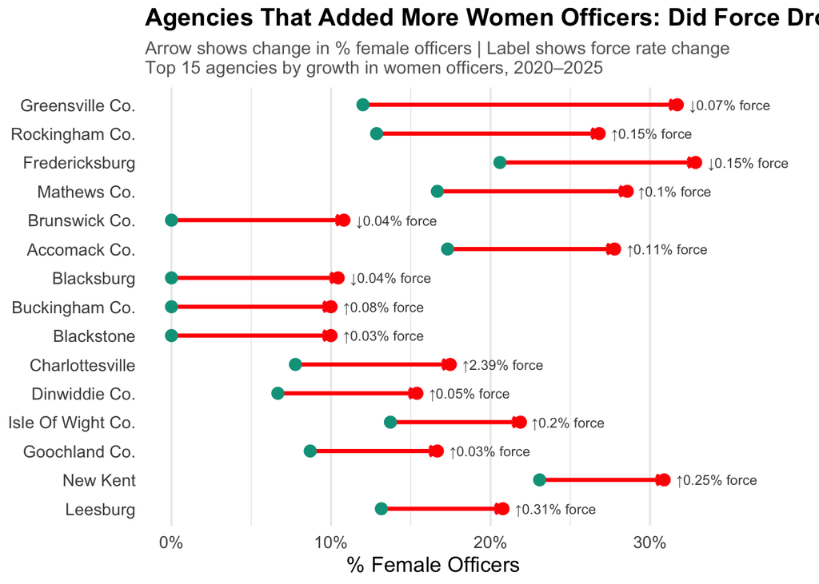

```r
# Track female officer % and force rate by agency over time
agency_over_time <- VAStops %>%
  filter(!is.na(county_clean), !is.na(officer_ct), officer_ct > 0) %>%
  group_by(agency_name, year) %>%
  summarize(
    total_stops = n(),
    force_count = sum(force_used_by_officer == "Y", na.rm = TRUE),
    force_rate = force_count / total_stops * 100,
    female_officers = first(na.omit(female_officer_ct)),
    total_officers = first(na.omit(officer_ct)),
    pct_female = female_officers / total_officers * 100,
    .groups = "drop"
  ) %>%
  filter(total_stops >= 500, !is.na(pct_female), force_count > 0)

# Pick agencies with biggest increase in female officers
female_change <- agency_over_time %>%
  group_by(agency_name) %>%
  filter(n() >= 3) %>%  # need at least 3 years of data
  summarize(
    start_pct = first(pct_female),
    end_pct = last(pct_female),
    change_female = end_pct - start_pct,
    start_force = first(force_rate),
    end_force = last(force_rate),
    change_force = end_force - start_force,
    .groups = "drop"
  ) %>%
  mutate(agency_short = agency_name %>%
           str_replace(" Police Department", "") %>%
           str_replace(" Police Dept", "") %>%
           str_replace(" Sheriff's Office", "") %>%
           str_replace(" County", " Co.") %>%
           str_trim()
  ) %>%
  filter(abs(change_female) > 0) %>%
  arrange(desc(change_female)) %>%
  head(15)

# Arrow chart: each agency shows where it started and ended
female_change %>%
  ggplot(aes(y = reorder(agency_short, change_female))) +
  geom_segment(aes(x = start_pct, xend = end_pct,
                   yend = agency_short),
               arrow = arrow(length = unit(0.2, "cm")),
               linewidth = 1.2,
               color = wes_palette("Darjeeling1")[1]) +
  geom_point(aes(x = start_pct), size = 3, color = wes_palette("Darjeeling1")[2]) +
  geom_point(aes(x = end_pct), size = 3, color = wes_palette("Darjeeling1")[1]) +
  geom_text(aes(x = end_pct,
                label = paste0(ifelse(change_force < 0, "↓", "↑"),
                               abs(round(change_force, 2)), "% force")),
            hjust = -0.15, size = 3, color = "gray30") +
  coord_cartesian(clip = "off") +
  scale_x_continuous(labels = function(x) paste0(round(x), "%")) +
  labs(
    title = "Agencies That Added More Women Officers: Did Force Drop?",
    subtitle = "Arrow shows change in % female officers | Label shows force rate change\nTop 15 agencies by growth in women officers, 2020–2025",
    x = "% Female Officers", y = NULL
  ) +
  theme_minimal(base_size = 13) +
  theme(
    plot.title = element_text(face = "bold", size = 15),
    plot.subtitle = element_text(color = "gray40", size = 11),
    panel.grid.major.y = element_blank(),
    plot.margin = margin(5, 60, 5, 5)
  )
```

Evidently, some agencies followed this hypothesis.

## Women in the Police Workforce on the Use of Force: A Geographical Representation

```r
#Map version
library(leaflet)
library(sf)

# Summarize change over time by agency + county
agency_change <- VAStops %>%
  filter(!is.na(county_clean), !is.na(officer_ct), officer_ct > 0) %>%
  group_by(agency_name, county_clean, year) %>%
  summarize(
    total_stops = n(),
    force_count = sum(force_used_by_officer == "Y", na.rm = TRUE),
    force_rate = force_count / total_stops * 100,
    female_officers = first(na.omit(female_officer_ct)),
    total_officers = first(na.omit(officer_ct)),
    pct_female = female_officers / total_officers * 100,
    .groups = "drop"
  ) %>%
  filter(total_stops >= 500, !is.na(pct_female), force_count > 0)

# Calculate change per county (aggregate agencies within county)
county_change <- agency_change %>%
  group_by(county_clean, year) %>%
  summarize(
    total_stops = sum(total_stops),
    force_count = sum(force_count),
    force_rate = force_count / total_stops * 100,
    female_officers = sum(female_officers),
    total_officers = sum(total_officers),
    pct_female = female_officers / total_officers * 100,
    .groups = "drop"
  ) %>%
  group_by(county_clean) %>%
  filter(n() >= 2) %>%
  summarize(
    start_year = first(year),
    end_year = last(year),
    start_pct_female = first(pct_female),
    end_pct_female = last(pct_female),
    change_female = round(end_pct_female - start_pct_female, 2),
    start_force = first(force_rate),
    end_force = last(force_rate),
    change_force = round(end_force - start_force, 3),
    avg_stops = round(mean(total_stops)),
    .groups = "drop"
  )

county_change <- county_change %>%
  mutate(county_clean = county_clean %>%
           str_replace(" CO$", "") %>%
           str_replace("City City City", "City") %>%
           str_replace("City City", "City") %>%
           str_replace("County City", "") %>%
           str_trim()
  )

# Then merge
va_map_change <- va_counties %>%
  left_join(county_change, by = "county_clean") %>%
  st_transform(4326)

# Filter out NAs for the palette domain
pal <- colorNumeric(
  palette = colorRampPalette(wes_palette("Zissou1"))(100),
  domain = va_map_change$change_female[!is.na(va_map_change$change_female)],
  na.color = "gray85"
)

# Hover labels
labels <- sprintf(
  "<strong>%s</strong><br/>
  <hr style='margin:4px 0'>
  <b>Women Officers:</b> %.1f%% → %.1f%% (%s%.1f%%)<br/>
  <b>Force Rate:</b> %.3f%% → %.3f%% (%s%.3f%%)<br/>
  <b>Avg Annual Stops:</b> %s<br/>
  <b>Period:</b> %s–%s",
  va_map_change$county_clean,
  va_map_change$start_pct_female,
  va_map_change$end_pct_female,
  ifelse(va_map_change$change_female >= 0, "+", ""),
  va_map_change$change_female,
  va_map_change$start_force,
  va_map_change$end_force,
  ifelse(va_map_change$change_force >= 0, "+", ""),
  va_map_change$change_force,
  scales::comma(va_map_change$avg_stops),
  va_map_change$start_year,
  va_map_change$end_year
) %>% lapply(htmltools::HTML)

leaflet(va_map_change) %>%
  addProviderTiles(providers$CartoDB.Positron) %>%
  addPolygons(
    fillColor = ~pal(change_female),
    weight = 1,
    color = "white",
    fillOpacity = 0.7,
    highlight = highlightOptions(
      weight = 3,
      color = "#333",
      fillOpacity = 0.9,
      bringToFront = TRUE
    ),
    label = labels,
    labelOptions = labelOptions(
      style = list("font-size" = "13px", "padding" = "8px"),
      textsize = "13px",
      direction = "auto"
    )
  ) %>%
  addLegend(
    pal = pal,
    values = ~change_female,
    title = "Change in %<br/>Women Officers",
    position = "bottomright"
  )
```

[interactive chart not shown]

# Key Takeaways

While we focused largely on race, we also found interesting trends with policing and poverty. We see evidence that police are largely centralized in more impoverished communities, speaking to the ways policing is seen as a way to tackle poverty in Virginia. Taken together, the visuals suggest that disparities are not limited to who is stopped but can persist in how individuals are treated during police encounters.

We also observed the impact of women officers in the agencies across the state. We hypothesized that women officers in a police agency would decrease the use of force by County overall. We found some weak effects for some smaller counties’ agencies. This may be a result of women constituting a larger proportion of officers within the agency, compared to bigger counties that might have more officers overall.

All in all, we hope our findings illustrate the problem at hand: Black or African American, and Hispanic Virginians face more negative outcomes when being stopped than white Virginians. It is essential to also consider the impact of each agency reporting these outcomes with their own discretion.

## Limitations

There are quite a few limitations to this data report due to the nature of the analysis and the data sources. One limitation is that much of the analysis required matching larger county level data (i.e the census) and police agency level data (i.e. the police workforce data) to the individual stops. While counties mapped onto each other relatively easily, the police agencies in the stops data did not always match 1 to 1 with the police workforce data. For example, the stops dataset referred to the Metropolitan Washington Airports Authority Police, which is an agency that focuses on police support at Reagan and Dulles airports, while the agency data includes Reagan National Airport police, with no reference to Dulles or the Washington Airports Authority. Further, there were stops with no assigned agency information, such as the different VSP (Virginia State Police) offices, which were mostly excluded from analysis.

The largest limitation to this report is that the stops data comes exclusively from police officers themselves. This means that officers define what constitutes a stops and use of force, which may be different across counties, agencies, and individual officers. This may be a concern if there’s not uniformity in the collection of this data. Moreover, officers are reporting the race of the resident stopped, which could lead to mislabeling a person’s identity based on physical features rather than the residents sharing their identity directly. This can be especially prevalent for residents who may physically resemble a racial or ethnic background that they are not. There was also no information on if a resident was multiracial, so we could not conclude what their relationship with policing is.